# GIScience class final report

人口と鉄道情報からみた埼玉県内のカーシェアリングサービス

長島せりあ

2022/06/30

## 0. 要旨

カーシェアリングが普及し始めている日本において、身近な地域である埼玉県を取り上げ、どのような地域にカーシェアリングの拠点が設置されているのか現状を考察した。

## 1. はじめに

### 1.1 背景

1940年にスイスで始まったカーシェアリングは、経済的に自動車を持つことができない市民に向けたサービスであった。 その後大気汚染や地球温暖化などの環境問題に配慮するため、カーシェアリングは世界各地で普及し始めている(“カーシェアリングの歴史,” n.d.)。 日本におけるカーシェアはスイスに比べはるかに低いが、自然環境や公共機関の発達度、財政状況などがスイスと似ていることから、今後の発展が期待できるとされている。

### 1.2 目的

埼玉県内のカーシェアリングの現状を、拠点データと埼玉県のいくつかの情報を用いて考察する。

## 2. 手法

埼玉県内のカーシェアリングが設けられている拠点の位置データと鉄道情報、 さらに埼玉県内の市町別の人口データの3つを利用して地図を作成する。

## 3. データ

・埼玉県内のカーシェアリング拠点の位置と数(“カーシェアリング・ステーション統計情報” 2020)  
・埼玉県内の鉄道路線(“日本の鉄道地図データ,” n.d.)  
・埼玉県内の市町別の人口(人口統計担当 2020)

## 4. 結果・考察

作成した地図は“6.Graphic Abstract”のようになった。 作成した地図から、線路沿いにカーシェアリングの拠点が多いことが読み取れる。 また、人口の多い市や町の拠点数が多いこともわかる。 さらに、東京寄りになるほど拠点が増えているとも言える。

## 5. 結論

今回の地図の作成により、カーシェアリングの拠点が多い場所は、  
・鉄道などの公共交通機関が発達している地域  
・人口が多い地域  
・首都寄りの地域  
であることが分かった。

## 6. Graphic Abstract

レポートを表す１枚の図をここで示す。

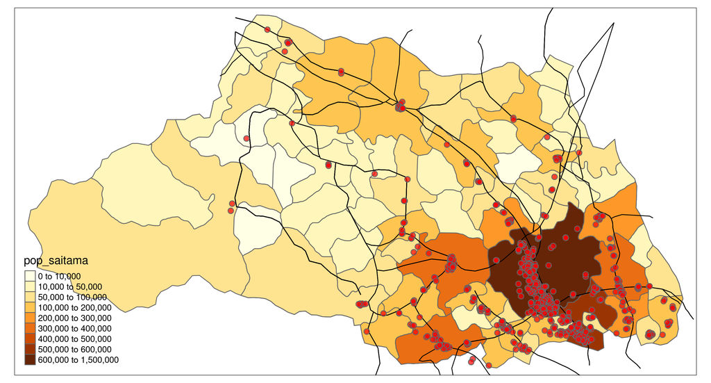

## 7. 参考文献

“カーシェアリング・ステーション統計情報.” 2020.

“カーシェアリングの歴史.” n.d.

人口統計担当. 2020. “令和２年国勢調査速報結果.”

“日本の鉄道地図データ.” n.d. *Https://Www.diva-Gis.org/Gdata*.